# **Fatal Police Shootings Since 2015: Now with Census Data!**

Carlos Loya, Tolan Nguyen, Robin Stewart

# **Introduction**

Police shootings has been in the nightly news for as long as TV has existed, yet each new shooting brings everyone to shilling realizations. This study aims to shed some light on such dark themes and equip people with the facts.

This data is a list of fatal police shootings from 2015 as recorded by the Washington Post that details the deaths of United States citizens at the hands of police officers. It includes information of the names of the citizens, the manner of death, if the citizen was armed, age, gender, city, and date.

Due to the personal nature of loss, the research team omitted the names of the deceased out of respect.

# **Obtaining The Data Set**

The data set was originally found on data.world, uploaded by a user named carlvlewis who claims that the data set is updated daily. For the purpose of this study we used the latest verison of the data that was available.

The data that was originally obtained was raw and contained private information regarding real people, so the data was cleaned using the lapply and gsub functions. The team removed the names of the deceased and made the race variable clearer. This cleaned data set was upload to the project data set on data.world.

To obtain a copy of this data follow the following steps.

1. Copy and paste the following link into your prefered web browser: https://data.world/robin-stewart/s-17-dv-project-6
   1. At the top-right section of your screen is a blue download button, that when clicked will download a zip file of the data set.
   2. Alternatively, scroll down to see a sample of the csv dataset. Click on the download button located to the right of the Explore button to download a csv file of the data set.

The following is a summary of the cleaned data set:

`r`r summary(fatalPoliceShootings)

```
       X                id               date            manner_of_death        armed
 Min.   :  1.00   Min.   :   3   2016-01-27: 8   shot            :91     gun       :55
 1st Qu.: 25.75   1st Qu.:1164   2016-01-16: 6   shot and Tasered: 9     knife     :16
 Median : 50.50   Median :1188   2016-01-17: 5                           toy weapon:11
 Mean   : 50.50   Mean   :1067   2016-01-18: 5                           unarmed   : 7
 3rd Qu.: 75.25   3rd Qu.:1219   2016-01-31: 5                           vehicle   : 7
 Max.   :100.00   Max.   :1288   2016-02-04: 5                           chain saw : 1
                                 (Other)   :66                           (Other)   : 3
      age           gender                race             city        state
 Min.   :12.00   FEMALE: 6   ASIAN          : 2   Kansas City: 2   CA     :15
 1st Qu.:28.00   MALE  :94   BLACK          :17   Mesa       : 2   TX     : 8
 Median :35.50               HISPANIC       :18   San Antonio: 2   OR     : 6
 Mean   :36.91               NATIVE AMERICAN: 3   Acworth    : 1   AL     : 5
 3rd Qu.:45.00               OTHER          : 1   Albuquerque: 1   FL     : 5
 Max.   :64.00               WHITE          :58   Aloha      : 1   TN     : 5
                             NA's           : 1   (Other)    :91   (Other):56
 signs_of_mental_illness threat_level          flee    body_camera
 false:66                attack:57    Car        :18   false:87
 true :34                other :43    Foot       :16   true :13
                                      Not fleeing:63
                                      Other      : 3
```

# **Census Data**

The U.S. Census Bureau and data.world have recently anounced a partnership which has resulted in data.world being host of the Census Bureau’s biggest annual household survey, the American Community Suvery.

Through the official US Census Buearu data.world profile, census data will be offered for any person to use and analyze: https://data.world/uscensusbureau

We used a 2011-2015 Income of US Population Estimates data for this particular study. This dataset was found here: https://data.world/uscensusbureau/acs-2015-5-e-income

Using the data.world R package, the 2011-2015 Income of US Population dataset and the Fatal Police Shootings were queried and pulled into RStudio and combined using dplyr.

Here is a summary of the combined dataset:

`r`r summary(incomeOfTheFatallyShot)

```
       X              State         GINI        Per_Capita_Income Median_Family_Income
 Min.   :  1.00   CA     :15   Min.   :0.4181   Min.   :22798     Min.   :51782
 1st Qu.: 25.75   TX     : 8   1st Qu.:0.4618   1st Qu.:25737     1st Qu.:57856
 Median : 50.50   OR     : 6   Median :0.4753   Median :26999     Median :62717
 Mean   : 50.50   AL     : 5   Mean   :0.4706   Mean   :27979     Mean   :64588
 3rd Qu.: 75.25   FL     : 5   3rd Qu.:0.4801   3rd Qu.:30318     3rd Qu.:70720
 Max.   :100.00   TN     : 5   Max.   :0.5317   Max.   :47675     Max.   :90089
                  (Other):56
 Median_Non_Family_Income Median_Income         id               date
 Min.   :23027            Min.   :41371   Min.   :   3   2016-01-27: 8
 1st Qu.:28639            1st Qu.:47507   1st Qu.:1164   2016-01-16: 6
 Median :31848            Median :51243   Median :1188   2016-01-17: 5
 Mean   :33022            Mean   :53300   Mean   :1067   2016-01-18: 5
 3rd Qu.:37909            3rd Qu.:61062   3rd Qu.:1219   2016-01-31: 5
 Max.   :61466            Max.   :74551   Max.   :1288   2016-02-04: 5
                                                         (Other)   :66
         manner_of_death        armed         age           gender                race
 shot            :91     gun       :55   Min.   :12.00   FEMALE: 6   ASIAN          : 2
 shot and Tasered: 9     knife     :16   1st Qu.:28.00   MALE  :94   BLACK          :17
                         toy weapon:11   Median :35.50               HISPANIC       :18
                         unarmed   : 7   Mean   :36.91               NATIVE AMERICAN: 3
                         vehicle   : 7   3rd Qu.:45.00               OTHER          : 1
                         chain saw : 1   Max.   :64.00               WHITE          :58
                         (Other)   : 3                               NA's           : 1
          city    signs_of_mental_illness threat_level          flee    body_camera
 Kansas City: 2   false:66                attack:57    Car        :18   false:87
 Mesa       : 2   true :34                other :43    Foot       :16   true :13
 San Antonio: 2                                        Not fleeing:63
 Acworth    : 1                                        Other      : 3
 Albuquerque: 1
 Aloha      : 1
 (Other)    :91
```

The columns of GINI, Per_Capita_Income, Median_Family_Income, and Median_Non_Family_Income were added from the census data and matched on state of the individual shot. This dataset was saved as a CSV for later use in Tablaeu and R Markdown.

# **Tablaeu Visualizations**

To create interesting visualizations, we must first understand what the combined data means. The columns that were queried from data.world were GINI, Per_Capita_Income, Median_Family_Income, and Median_Non_Family_Income. These are state-level summaries, meaning that each fatal shootings has per capita income, median family income, median non-family income information based on the state in which the shooting took place. Although this mixes individualized data with general data, it sheds some light into the type of environment and socioeconomic context the shooting took place.

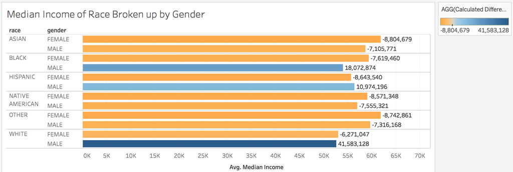

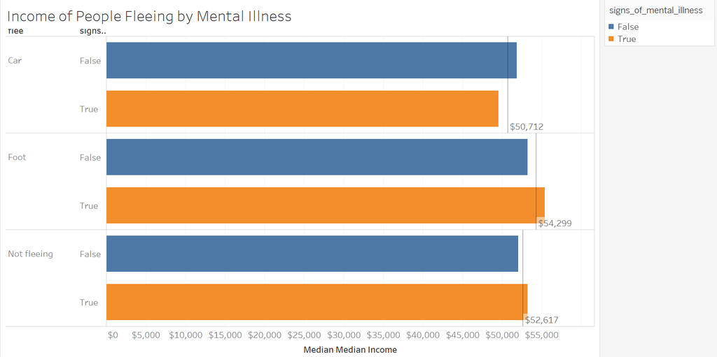

Median Income by Fleeing

This is a barhart depicting income of how people are fleeing, separated by signs of mental illness. The line shows the average of median incomes by mental illness and feeling type.

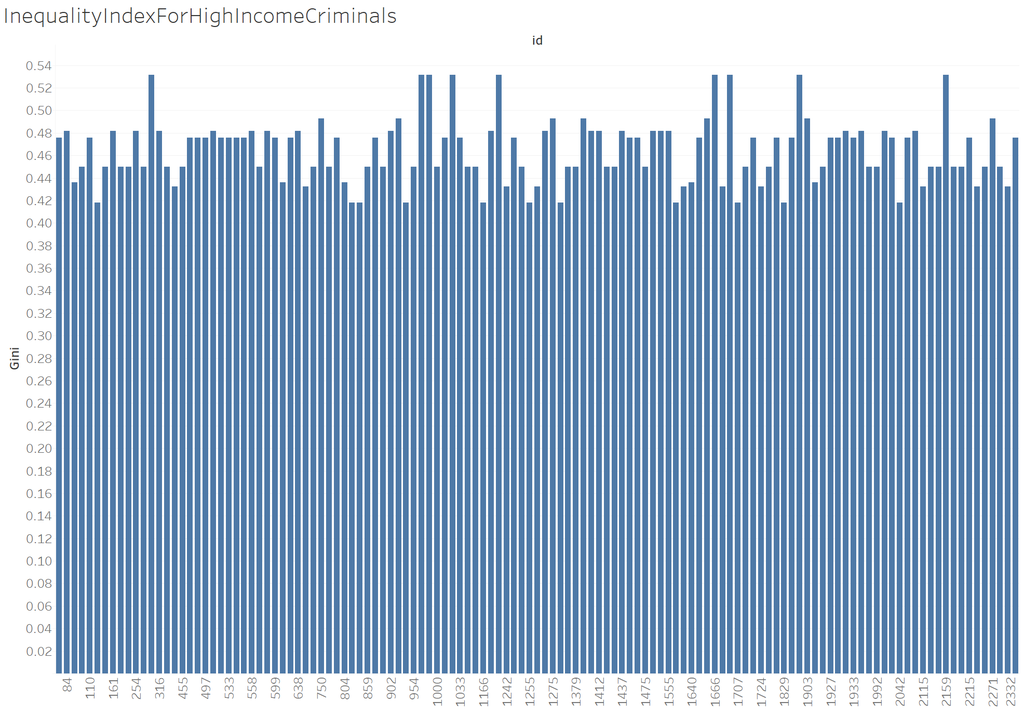

Inequality Index for High Income Criminals

This barchart shows the GINI inequality index of the area criminals are from, using ID-sets to separate high income criminals.

# **R Visualizations**

The following are visualizations created using ggplot2 and dplyr in R Studio. They are based off of the above Tablaeu graphs.

`r`r plot(incomeByRacePlot)

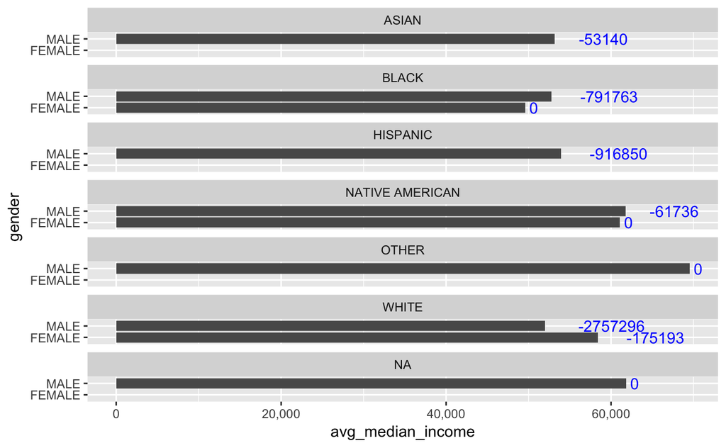

`r`r plot(fleePlot)

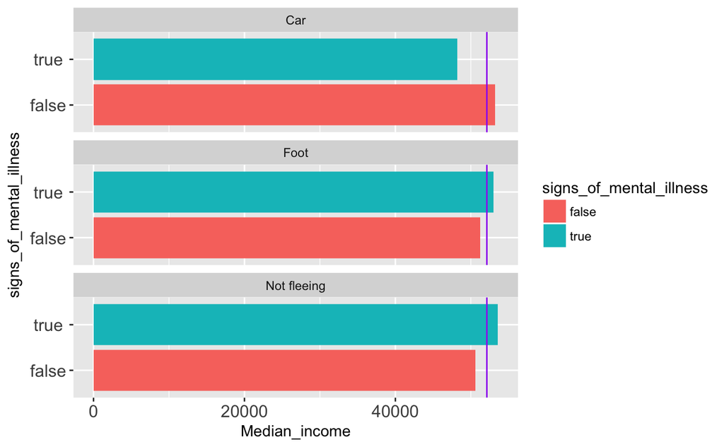

`r`r plot(inequalityPlot)

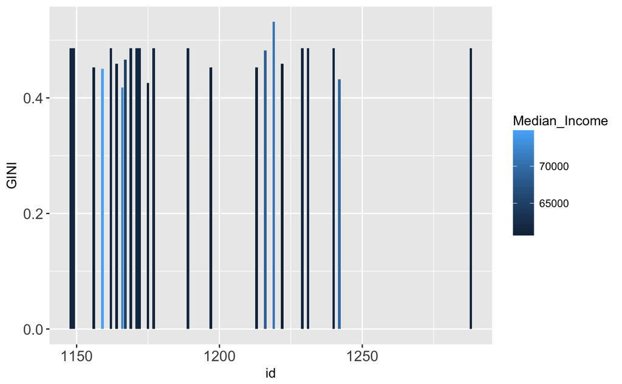

This barchart shows the GINI inequality index of the area criminals are from, using ID-sets to separate high income criminals.

Lastly, all the R visualizations were put on the same png file using the grid R package:

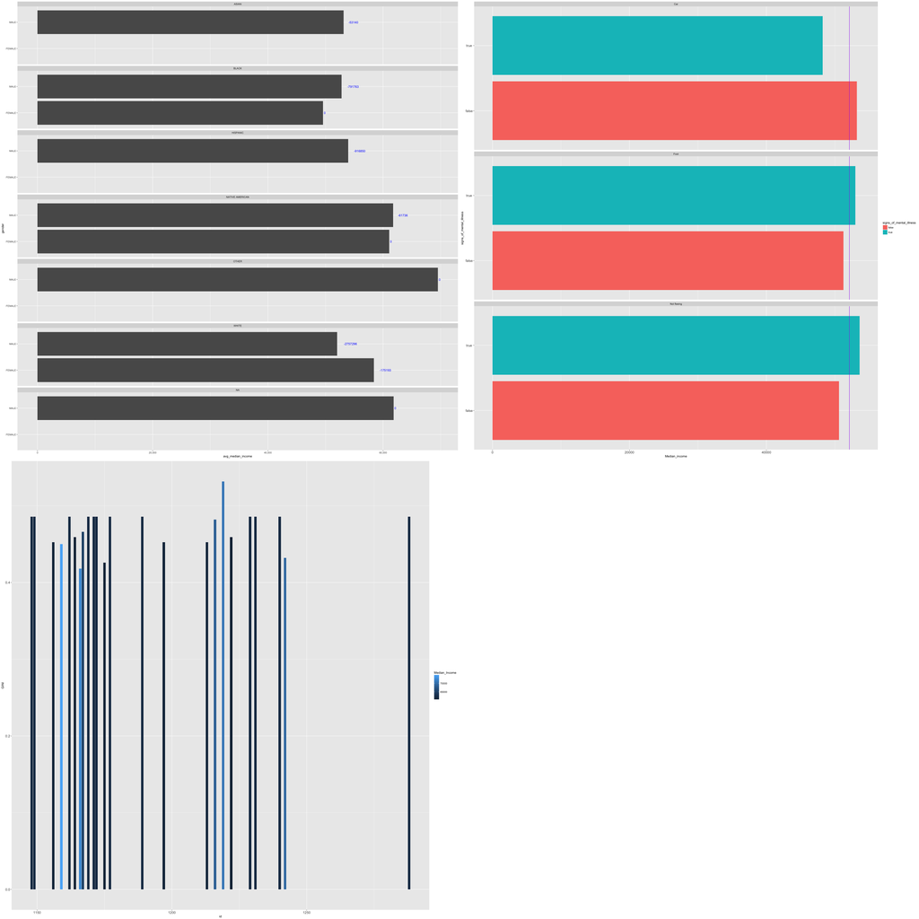

Joint Plots

# **R Shiny**

All R visualizations were graphed on crosstabs in R Shiny. Each graph in each of the different tabs. Here is a link to the published shiny application: https://carlosloya.shinyapps.io/dvproject6shinyapplication/

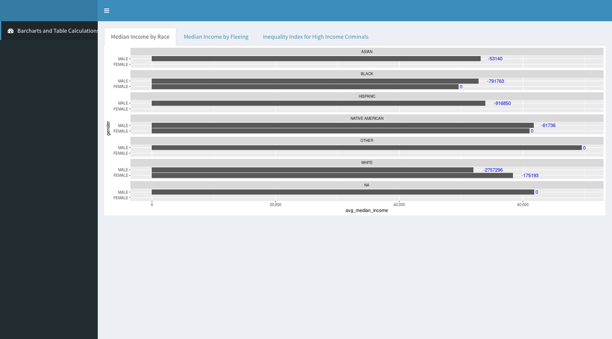

Online Shiny Application